# A3

Maitri Shah

5/26/2021

Question 1- Load the NYC Green Taxi Trip Records data directly from the URL into a data frame called tripdata_df. Inspect the data to identify its dimensions and the frequency of missing values. Helpful functions: dim(), glimpse() and summary(). Tip: it is also good practice to inspect the data type for each field/column to determine if the data was imported correctly.

```r
library(tidyverse)
```

```r
library(ggplot2)
#Loading NYC taxi data
tripdata_df <- read_csv ("https://s3.amazonaws.com/nyc-tlc/trip+data/green_tripdata_2020-02.csv")
tripdata_df
```

```
## # A tibble: 398,632 x 20
##    VendorID lpep_pickup_datetime lpep_dropoff_datet… store_and_fwd_f… RatecodeID
##       <dbl> <dttm>               <dttm>              <chr>                 <dbl>
##  1        2 2020-02-01 00:10:25  2020-02-01 00:14:34 N                         1
##  2        2 2020-02-01 00:16:59  2020-02-01 00:21:35 N                         1
##  3        2 2020-02-01 00:19:31  2020-02-01 00:25:29 N                         1
##  4        2 2020-02-01 00:43:52  2020-02-01 00:48:58 N                         1
##  5        2 2020-02-01 00:32:53  2020-02-01 00:35:19 N                         1
##  6        2 2020-02-01 00:04:36  2020-02-01 00:10:09 N                         1
##  7        2 2020-02-01 00:49:36  2020-02-01 01:07:27 N                         1
##  8        2 2020-02-01 00:21:08  2020-02-01 00:28:16 N                         1
##  9        2 2020-02-01 00:05:16  2020-02-01 00:16:25 N                         1
## 10        2 2020-02-01 00:59:48  2020-02-01 01:06:26 N                         1
## # … with 398,622 more rows, and 15 more variables: PULocationID <dbl>,
## #   DOLocationID <dbl>, passenger_count <dbl>, trip_distance <dbl>,
## #   fare_amount <dbl>, extra <dbl>, mta_tax <dbl>, tip_amount <dbl>,
## #   tolls_amount <dbl>, ehail_fee <lgl>, improvement_surcharge <dbl>,
## #   total_amount <dbl>, payment_type <dbl>, trip_type <dbl>,
## #   congestion_surcharge <dbl>
```

```r
dim(tripdata_df)
```

```
## [1] 398632     20
```

```r
glimpse(tripdata_df)
```

```
## Rows: 398,632
## Columns: 20
## $ VendorID              <dbl> 2, 2, 2, 2, 2, 2, 2, 2, 2, 2, 2, 1, 2, 2, 1, 2, …
## $ lpep_pickup_datetime  <dttm> 2020-02-01 00:10:25, 2020-02-01 00:16:59, 2020-…
## $ lpep_dropoff_datetime <dttm> 2020-02-01 00:14:34, 2020-02-01 00:21:35, 2020-…
## $ store_and_fwd_flag    <chr> "N", "N", "N", "N", "N", "N", "N", "N", "N", "N"…
## $ RatecodeID            <dbl> 1, 1, 1, 1, 1, 1, 1, 1, 1, 1, 1, 4, 1, 1, 1, 1, …
## $ PULocationID          <dbl> 74, 74, 223, 145, 166, 166, 7, 112, 212, 212, 7,…
## $ DOLocationID          <dbl> 41, 74, 7, 145, 166, 41, 173, 80, 213, 58, 179, …
## $ passenger_count       <dbl> 1, 1, 1, 1, 1, 1, 1, 1, 3, 3, 1, 1, 1, 1, 1, 1, …
## $ trip_distance         <dbl> 0.76, 0.72, 0.89, 1.12, 0.65, 1.11, 2.89, 0.87, …
## $ fare_amount           <dbl> 4.5, 5.0, 6.0, 6.0, 4.0, 6.0, 14.0, 6.0, 10.0, 1…
## $ extra                 <dbl> 0.5, 0.5, 0.5, 0.5, 0.5, 0.5, 0.5, 0.5, 0.5, 0.5…
## $ mta_tax               <dbl> 0.5, 0.5, 0.5, 0.5, 0.5, 0.5, 0.5, 0.5, 0.5, 0.5…
## $ tip_amount            <dbl> 0.00, 0.00, 1.82, 0.00, 1.06, 0.00, 0.00, 0.00, …
## $ tolls_amount          <dbl> 0.00, 0.00, 0.00, 0.00, 0.00, 0.00, 0.00, 0.00, …
## $ ehail_fee             <lgl> NA, NA, NA, NA, NA, NA, NA, NA, NA, NA, NA, NA, …
## $ improvement_surcharge <dbl> 0.3, 0.3, 0.3, 0.3, 0.3, 0.3, 0.3, 0.3, 0.3, 0.3…
## $ total_amount          <dbl> 5.80, 6.30, 9.12, 7.30, 6.36, 7.30, 15.30, 7.30,…
## $ payment_type          <dbl> 2, 1, 1, 2, 1, 2, 2, 2, 2, 2, 1, 1, 1, 2, 1, 2, …
## $ trip_type             <dbl> 1, 1, 1, 1, 1, 1, 1, 1, 1, 1, 1, 1, 1, 1, 1, 1, …
## $ congestion_surcharge  <dbl> 0.00, 0.00, 0.00, 0.00, 0.00, 0.00, 0.00, 0.00, …
```

```r
#Data type
summary(tripdata_df)
```

```
##     VendorID     lpep_pickup_datetime          lpep_dropoff_datetime
##  Min.   :1.00    Min.   :2009-01-01 00:47:21   Min.   :2009-01-01 00:47:47
##  1st Qu.:2.00    1st Qu.:2020-02-08 04:56:13   1st Qu.:2020-02-08 05:29:55
##  Median :2.00    Median :2020-02-15 07:30:30   Median :2020-02-15 07:58:40
##  Mean   :1.83    Mean   :2020-02-15 16:59:54   Mean   :2020-02-15 17:20:00
##  3rd Qu.:2.00    3rd Qu.:2020-02-23 00:28:25   3rd Qu.:2020-02-23 00:47:24
##  Max.   :2.00    Max.   :2020-03-01 06:34:53   Max.   :2020-03-01 22:50:53
##  NA's   :80893
##  store_and_fwd_flag   RatecodeID     PULocationID    DOLocationID
##  Length:398632      Min.   : 1.0    Min.   :  1.0   Min.   :  1.0
##  Class :character   1st Qu.: 1.0    1st Qu.: 52.0   1st Qu.: 65.0
##  Mode  :character   Median : 1.0    Median : 82.0   Median :129.0
##                     Mean   : 1.1    Mean   :107.9   Mean   :129.4
##                     3rd Qu.: 1.0    3rd Qu.:166.0   3rd Qu.:193.0
##                     Max.   :99.0    Max.   :265.0   Max.   :265.0
##                     NA's   :80893
##  passenger_count trip_distance        fare_amount          extra
##  Min.   :0.00    Min.   :     0.00   Min.   :-150.00   Min.   :-4.5000
##  1st Qu.:1.00    1st Qu.:     1.04   1st Qu.:   7.00   1st Qu.: 0.0000
##  Median :1.00    Median :     1.97   Median :  11.00   Median : 0.5000
##  Mean   :1.31    Mean   :     4.91   Mean   :  15.32   Mean   : 0.8915
##  3rd Qu.:1.00    3rd Qu.:     4.08   3rd Qu.:  20.06   3rd Qu.: 1.0000
##  Max.   :8.00    Max.   :159907.16   Max.   : 458.00   Max.   :16.7400
##  NA's   :80893
##     mta_tax          tip_amount        tolls_amount     ehail_fee
##  Min.   :-0.5000   Min.   :-10.5600   Min.   : 0.0000   Mode:logical
##  1st Qu.: 0.5000   1st Qu.:  0.0000   1st Qu.: 0.0000   NA's:398632
##  Median : 0.5000   Median :  0.0000   Median : 0.0000
##  Mean   : 0.4012   Mean   :  0.9864   Mean   : 0.2823
##  3rd Qu.: 0.5000   3rd Qu.:  1.6600   3rd Qu.: 0.0000
##  Max.   : 3.5500   Max.   :641.2000   Max.   :33.6200
##
##  improvement_surcharge  total_amount      payment_type     trip_type
##  Min.   :-0.3000       Min.   :-150.30   Min.   :1.00    Min.   :1.00
##  1st Qu.: 0.3000       1st Qu.:   8.80   1st Qu.:1.00    1st Qu.:1.00
##  Median : 0.3000       Median :  14.12   Median :1.00    Median :1.00
##  Mean   : 0.2918       Mean   :  18.50   Mean   :1.45    Mean   :1.02
##  3rd Qu.: 0.3000       3rd Qu.:  24.30   3rd Qu.:2.00    3rd Qu.:1.00
##  Max.   : 0.3000       Max.   : 651.50   Max.   :5.00    Max.   :2.00
##                                          NA's   :80893   NA's   :80894
##  congestion_surcharge
##  Min.   :0.00
##  1st Qu.:0.00
##  Median :0.00
##  Mean   :0.47
##  3rd Qu.:0.00
##  Max.   :2.75
##  NA's   :80893
```

```r
str(tripdata_df)
```

```
## spec_tbl_df[,20] [398,632 × 20] (S3: spec_tbl_df/tbl_df/tbl/data.frame)
##  $ VendorID             : num [1:398632] 2 2 2 2 2 2 2 2 2 2 ...
##  $ lpep_pickup_datetime : POSIXct[1:398632], format: "2020-02-01 00:10:25" "2020-02-01 00:16:59" ...
##  $ lpep_dropoff_datetime: POSIXct[1:398632], format: "2020-02-01 00:14:34" "2020-02-01 00:21:35" ...
##  $ store_and_fwd_flag   : chr [1:398632] "N" "N" "N" "N" ...
##  $ RatecodeID           : num [1:398632] 1 1 1 1 1 1 1 1 1 1 ...
##  $ PULocationID         : num [1:398632] 74 74 223 145 166 166 7 112 212 212 ...
##  $ DOLocationID         : num [1:398632] 41 74 7 145 166 41 173 80 213 58 ...
##  $ passenger_count      : num [1:398632] 1 1 1 1 1 1 1 1 3 3 ...
##  $ trip_distance        : num [1:398632] 0.76 0.72 0.89 1.12 0.65 1.11 2.89 0.87 2.18 3.19 ...
##  $ fare_amount          : num [1:398632] 4.5 5 6 6 4 6 14 6 10 10.5 ...
##  $ extra                : num [1:398632] 0.5 0.5 0.5 0.5 0.5 0.5 0.5 0.5 0.5 0.5 ...
##  $ mta_tax              : num [1:398632] 0.5 0.5 0.5 0.5 0.5 0.5 0.5 0.5 0.5 0.5 ...
##  $ tip_amount           : num [1:398632] 0 0 1.82 0 1.06 0 0 0 0 0 ...
##  $ tolls_amount         : num [1:398632] 0 0 0 0 0 0 0 0 0 0 ...
##  $ ehail_fee            : logi [1:398632] NA NA NA NA NA NA ...
##  $ improvement_surcharge: num [1:398632] 0.3 0.3 0.3 0.3 0.3 0.3 0.3 0.3 0.3 0.3 ...
##  $ total_amount         : num [1:398632] 5.8 6.3 9.12 7.3 6.36 7.3 15.3 7.3 11.3 11.8 ...
##  $ payment_type         : num [1:398632] 2 1 1 2 1 2 2 2 2 2 ...
##  $ trip_type            : num [1:398632] 1 1 1 1 1 1 1 1 1 1 ...
##  $ congestion_surcharge : num [1:398632] 0 0 0 0 0 0 0 0 0 0 ...
##  - attr(*, "spec")=
##   .. cols(
##   ..   VendorID = col_double(),
##   ..   lpep_pickup_datetime = col_datetime(format = ""),
##   ..   lpep_dropoff_datetime = col_datetime(format = ""),
##   ..   store_and_fwd_flag = col_character(),
##   ..   RatecodeID = col_double(),
##   ..   PULocationID = col_double(),
##   ..   DOLocationID = col_double(),
##   ..   passenger_count = col_double(),
##   ..   trip_distance = col_double(),
##   ..   fare_amount = col_double(),
##   ..   extra = col_double(),
##   ..   mta_tax = col_double(),
##   ..   tip_amount = col_double(),
##   ..   tolls_amount = col_double(),
##   ..   ehail_fee = col_logical(),
##   ..   improvement_surcharge = col_double(),
##   ..   total_amount = col_double(),
##   ..   payment_type = col_double(),
##   ..   trip_type = col_double(),
##   ..   congestion_surcharge = col_double()
##   .. )
```

```r
#Missing value
tripdata_df$NA_frequency <- rowSums(apply (is.na (tripdata_df), 2, as.numeric))
tripdata_df
```

```
## # A tibble: 398,632 x 21
##    VendorID lpep_pickup_datetime lpep_dropoff_datet… store_and_fwd_f… RatecodeID
##       <dbl> <dttm>               <dttm>              <chr>                 <dbl>
##  1        2 2020-02-01 00:10:25  2020-02-01 00:14:34 N                         1
##  2        2 2020-02-01 00:16:59  2020-02-01 00:21:35 N                         1
##  3        2 2020-02-01 00:19:31  2020-02-01 00:25:29 N                         1
##  4        2 2020-02-01 00:43:52  2020-02-01 00:48:58 N                         1
##  5        2 2020-02-01 00:32:53  2020-02-01 00:35:19 N                         1
##  6        2 2020-02-01 00:04:36  2020-02-01 00:10:09 N                         1
##  7        2 2020-02-01 00:49:36  2020-02-01 01:07:27 N                         1
##  8        2 2020-02-01 00:21:08  2020-02-01 00:28:16 N                         1
##  9        2 2020-02-01 00:05:16  2020-02-01 00:16:25 N                         1
## 10        2 2020-02-01 00:59:48  2020-02-01 01:06:26 N                         1
## # … with 398,622 more rows, and 16 more variables: PULocationID <dbl>,
## #   DOLocationID <dbl>, passenger_count <dbl>, trip_distance <dbl>,
## #   fare_amount <dbl>, extra <dbl>, mta_tax <dbl>, tip_amount <dbl>,
## #   tolls_amount <dbl>, ehail_fee <lgl>, improvement_surcharge <dbl>,
## #   total_amount <dbl>, payment_type <dbl>, trip_type <dbl>,
## #   congestion_surcharge <dbl>, NA_frequency <dbl>
```

Question 2- Explore the data to determine if there are any inconsistent or invalid data; for example, examine the dates within the dataset to see if they align with your expectations (remember you downloaded a dataset for February 2020). Identify at least two things that stand out to you and remember that this is based on your observations about the data, so it’s important to demonstrate what you found.

```r
a <- tripdata_df %>%
  count(DOLocationID, sort= TRUE)
head(a)
```

```
## # A tibble: 6 x 2
##   DOLocationID     n
##          <dbl> <int>
## 1           74 15439
## 2           42 14342
## 3           41 13060
## 4           75 11313
## 5          129  9416
## 6          166  8892
```

```r
b <- tripdata_df %>%
  count(PULocationID, sort= TRUE)
head(b)
```

```
## # A tibble: 6 x 2
##   PULocationID     n
##          <dbl> <int>
## 1           74 31168
## 2           75 26271
## 3           41 23040
## 4          166 16679
## 5           82 16062
## 6            7 14453
```

#Another observation was the tip_amount. There are very inconsistent and unsual results when comparing tip_amount with fare amount. The summary() demonstrates that min tip amount is $-10.56 whereas max is $641 which is definitely an outlier and unusual. #The scatter plot shows the relation between tip amount and fare amount which is also very inconsistent. One example is; some trips with fare amount in between $0-$50 have tip amount around $100.

```r
summary(tripdata_df$tip_amount)
```

```
##     Min.  1st Qu.   Median     Mean  3rd Qu.     Max.
## -10.5600   0.0000   0.0000   0.9864   1.6600 641.2000
```

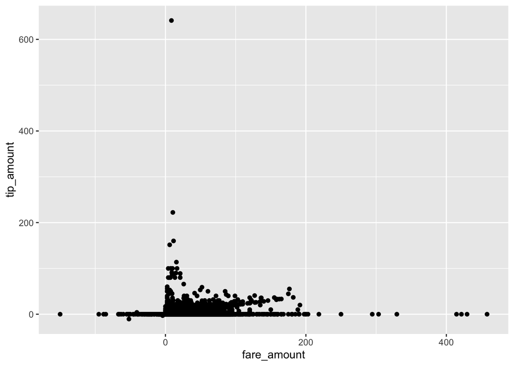

```r
ggplot (tripdata_df, aes(x= fare_amount, y= tip_amount)) +
  geom_point()
```

Question 3- Create a histogram, showing the trip_distance. Is the data skewed? Explain what you observed using 1-2 sentences. Note: you may need to rescale the y-axis using a log scale to improve the visualization.

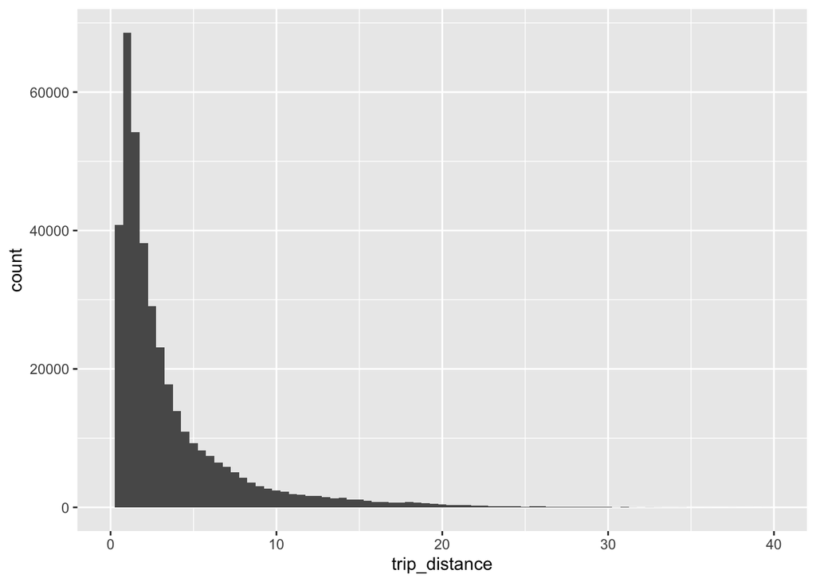

```r
ggplot(data = tripdata_df) +
  geom_histogram (mapping = aes(x = trip_distance), binwidth= 0.5) + xlim(c(0, 40))
```

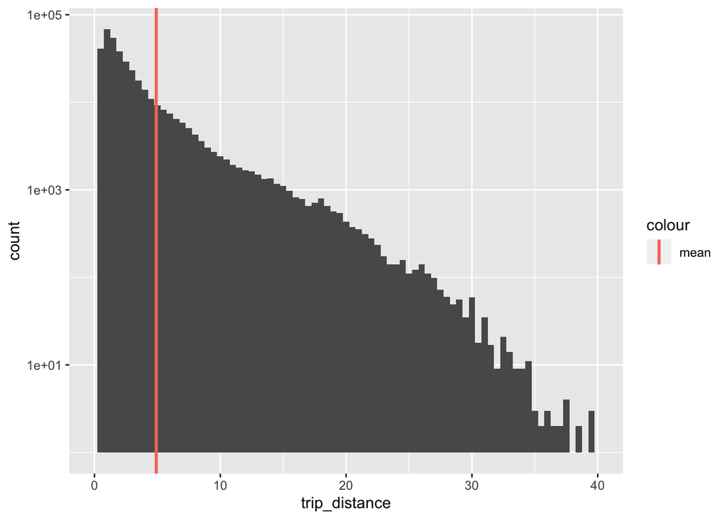

```r
#To calculate mean
ggplot(data = tripdata_df) +
  geom_histogram (mapping = aes(x = trip_distance), binwidth= 0.5) + xlim(c(0, 40)) +
  geom_vline(aes(xintercept = mean(trip_distance),colour = "mean"), linetype = "solid", lwd = 1) +
  scale_y_log10()
```

Question 4- Analyze the tip_amount to identify any outliers. You can assume the outliers are 3 standard deviations from the mean. Comment on the outliers that were detected; after which, remove the outlier tip_amount from the data.

```r
#Calculate mean, sd and z score
mean_df <- mean(tripdata_df$tip_amount)
sd_df <- sd (tripdata_df$tip_amount)
z_df <- abs((mean_df- tripdata_df$tip_amount)/ sd_df)
#Outliers are 3 z- scores away from either side of the mean
outliers <- tripdata_df[which(z_df >3),]
summary(outliers$tip_amount)
```

```
##    Min. 1st Qu.  Median    Mean 3rd Qu.    Max.
##  -10.56    8.25    9.47   11.61   11.76  641.20
```

```r
#The below code removes outliers
no.o <- tripdata_df[-which(z_df >3),]
dim (no.o)
```

```
## [1] 394884     21
```

Question 5- Filter the data from question 4 above, and create a suitable visualization to show the frequency of trips by payment_type (e.g. credit card, cash, etc). Ensure that your visualization(s) has a title and label both the x and y axis.

```r
no.o <- no.o %>%
  mutate (payment_type_label = fct_recode(factor(payment_type), "Credit card"="1",
                                  "Cash"="2",
                                   "No charge"="3",
                                   "Dispute"="4" ,
                                   "Unknown"= "5"))
no.o %>%
count(payment_type_label)
```

```
## # A tibble: 6 x 2
##   payment_type_label      n
##   <fct>               <int>
## 1 Credit card        172788
## 2 Cash               138849
## 3 No charge            1766
## 4 Dispute               579
## 5 Unknown                14
## 6 <NA>                80888
```

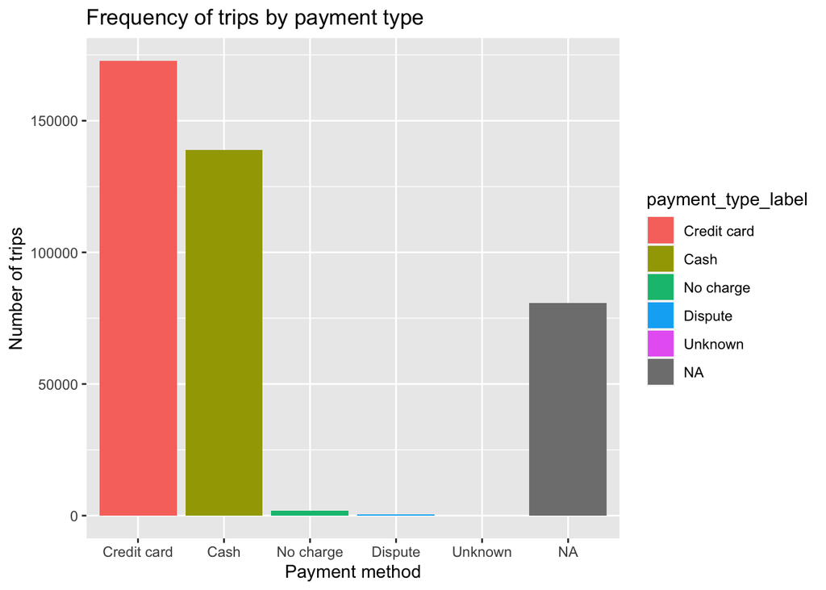

```r
ggplot(data= no.o) +
  geom_bar(aes (x= payment_type_label, fill= payment_type_label))+
  ggtitle("Frequency of trips by payment type") +
  xlab("Payment method") + ylab("Number of trips")
```

Question 6- State at least two methods/techniques that can be used to handle missing data. Which approach would you recommend, is suitable, to handle missing values in this dataset? Answer- Techniques to handle missing data are: 1) Omit them from the data set 2) Replace it with something. If is in an intrinsic missing value i.e. it is not present in the data frame, we can make it extrinsic by replacing with NA. for this the complete() as well as setting values_drop_na = TRUE in pivot_longer() can be done 3) We can also fill the missing values as per the last non-missing value using fill(). These can be used in cases when a data source is used for data entry.

For our data set, we should identify the missing data first using is.na(). Since the ehail_fee column is entirely missing it can be dropped, in all other places we can use na.rm()= TRUE to not consider missing values. In a bar graph, missing values are seen seperately and in a histogram, they are removed so the data integrity is maintained.